# Genome-wide methylation analysis report

# Genome-wide methylation analysis report

- study: Pleural cfDNAm analysis of meso_malig.platevariable
- author: Paul Yousefi
- date: 08 October, 2026

## Parameters

```
## $sig.threshold
## [1] 2.121143e-07
##
## $max.plots
## [1] 10
##
## $qq.inflation.method
## [1] "median"
##
## $practical.threshold
## [1] 0.0001164831
```

## Sample characteristics

For continuous or ordinal variables, the “mean” column provides the mean and the “sd/%” column the standard deviation of the variable. For categorical variables, the “mean” column provides the number of samples with the given “value” and the “sd/%” column the percentage of samples with the given “value”.

| variable | value | mean | sd.. |
| --- | --- | --- | --- |
| meso_malig |  | 0.3529412 | 0.4792964 |
| plate |  | 2.217647 | 1.046117 |
| sv1 |  | 1.884559e-18 | 0.07692308 |
| sv2 |  | 1.260056e-18 | 0.07692308 |
| sv3 |  | 1.710169e-18 | 0.07692308 |
| sv4 |  | -8.997284e-19 | 0.07692308 |
| sv5 |  | 3.6198e-18 | 0.07692308 |
| sv6 |  | 7.245978e-18 | 0.07692308 |
| sv7 |  | -4.166445e-18 | 0.07692308 |
| sv8 |  | -1.699694e-17 | 0.07692308 |
| sv9 |  | -1.149821e-15 | 0.07692308 |
| sv10 |  | -1.903303e-14 | 0.07692308 |

## Covariate associations

### Covariate plate

statistics

| var1 | var2 | F | p-value | R | p-value |
| --- | --- | --- | --- | --- | --- |
| meso_malig | plate | 0.3642161 | 0.546988 | 0.0463152 | 0.5486773 |

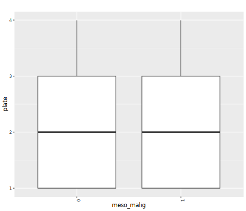

### Covariate sv1

statistics

| var1 | var2 | F | p-value | R | p-value |
| --- | --- | --- | --- | --- | --- |
| meso_malig | sv1 | 1.231201 | 0.2687593 | 0.0591956 | 0.4432039 |

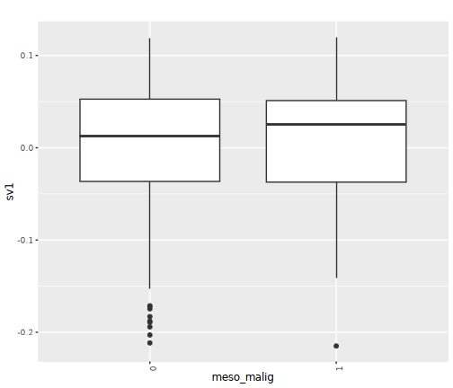

### Covariate sv2

statistics

| var1 | var2 | F | p-value | R | p-value |
| --- | --- | --- | --- | --- | --- |
| meso_malig | sv2 | 0.0034926 | 0.9529444 | -0.0674729 | 0.3819846 |

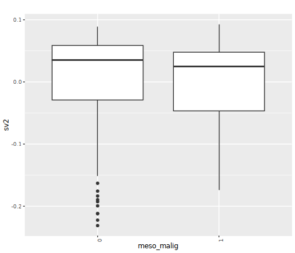

### Covariate sv3

statistics

| var1 | var2 | F | p-value | R | p-value |
| --- | --- | --- | --- | --- | --- |
| meso_malig | sv3 | 4.712595 | 0.0313457 | -0.1246619 | 0.1052914 |

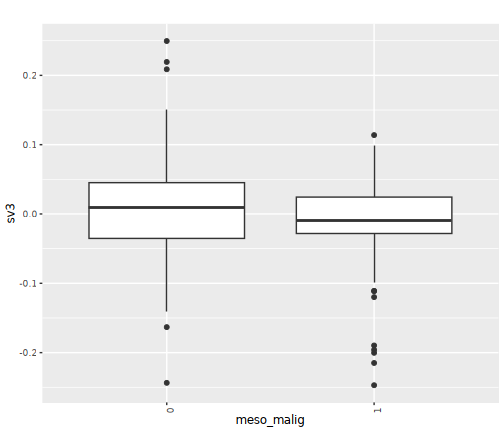

### Covariate sv4

statistics

| var1 | var2 | F | p-value | R | p-value |
| --- | --- | --- | --- | --- | --- |
| meso_malig | sv4 | 2.235883 | 0.1367156 | -0.1050972 | 0.1725768 |

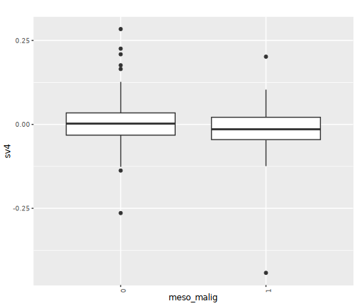

### Covariate sv5

statistics

| var1 | var2 | F | p-value | R | p-value |
| --- | --- | --- | --- | --- | --- |
| meso_malig | sv5 | 0.4449538 | 0.5056562 | 0.0486608 | 0.5285956 |

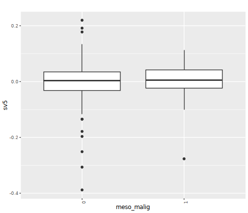

### Covariate sv6

statistics

| var1 | var2 | F | p-value | R | p-value |
| --- | --- | --- | --- | --- | --- |
| meso_malig | sv6 | 0.1575327 | 0.6919421 | -0.0130431 | 0.8659433 |

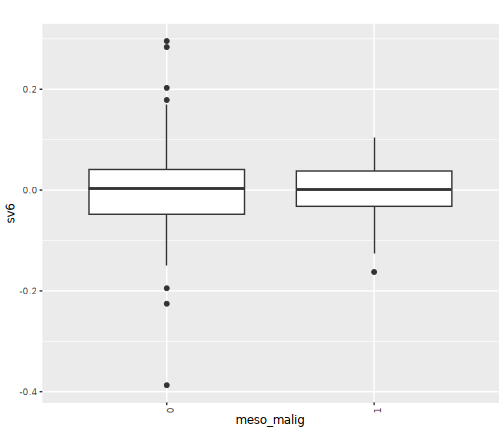

### Covariate sv7

statistics

| var1 | var2 | F | p-value | R | p-value |
| --- | --- | --- | --- | --- | --- |
| meso_malig | sv7 | 1.459682 | 0.2286786 | -0.1261668 | 0.1011226 |

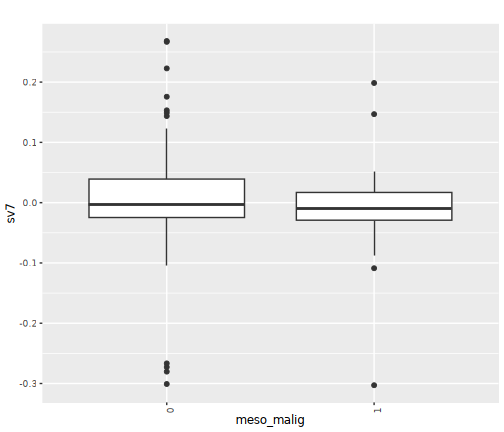

### Covariate sv8

statistics

| var1 | var2 | F | p-value | R | p-value |
| --- | --- | --- | --- | --- | --- |
| meso_malig | sv8 | 0.5608885 | 0.4549498 | -0.0870376 | 0.259066 |

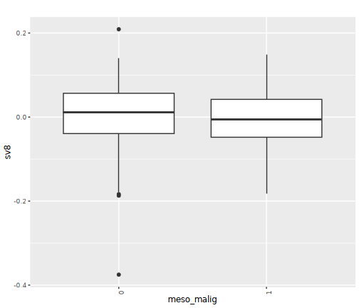

### Covariate sv9

statistics

| var1 | var2 | F | p-value | R | p-value |
| --- | --- | --- | --- | --- | --- |
| meso_malig | sv9 | 0.9847596 | 0.3224537 | 0.0589447 | 0.4451418 |

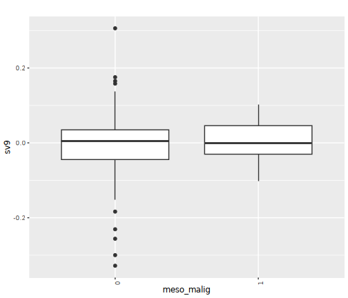

### Covariate sv10

statistics

| var1 | var2 | F | p-value | R | p-value |
| --- | --- | --- | --- | --- | --- |
| meso_malig | sv10 | 0.9301262 | 0.3362163 | -0.1071039 | 0.1644795 |

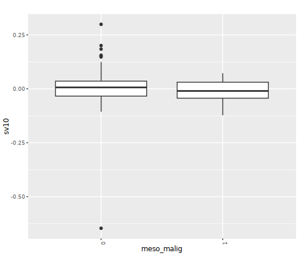

## QQ plots

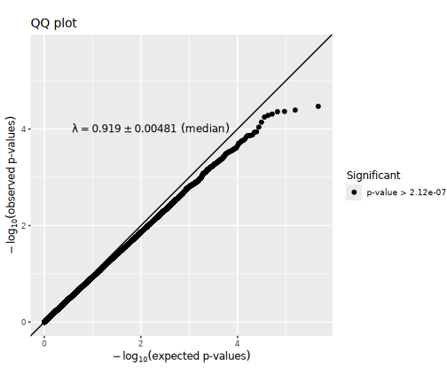

## Manhattan plots

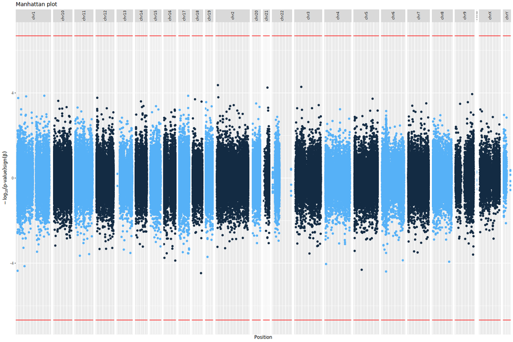

## Significant CpG sites

There were 0 CpG sites with association p-values < 2.1211427 × 10<sup>-7</sup>. These are listed in the file associations.csv.

Below are the 10 CpG sites with association p-values < 1.1648307 × 10<sup>-4</sup> in the regression model.

|  | chromosome | position | estimate | p.value | p.adjust |
| --- | --- | --- | --- | --- | --- |
| cg02380637 | chr2 | 7171893 | 0.0702776 | 0.0000431 | 1 |
| cg00049278 | chr1 | 2004925 | -0.0536257 | 0.0000437 | 1 |
| cg14263354 | chr9 | 129399976 | 0.0985954 | 0.0001136 | 1 |
| cg00806202 | chr1 | 55973099 | -0.0485806 | 0.0000720 | 1 |
| cg05080926 | chr6 | 31129626 | -0.0508502 | 0.0000404 | 1 |
| cg09639152 | chr3 | 45078075 | 0.0635546 | 0.0000521 | 1 |
| cg06170415 | chr4 | 4555850 | -0.0379673 | 0.0000909 | 1 |
| cg13333275 | chr18 | 68045800 | -0.0516430 | 0.0000338 | 1 |
| cg17458922 | chr21 | 32932343 | 0.0724171 | 0.0000564 | 1 |
| cg01164141 | chr5 | 55977468 | -0.0588201 | 0.0000489 | 1 |

Plots of these sites follow, one for each covariate set. “p[lm]” denotes the p-value obtained using a linear model and “p[beta]” the p-value obtained using beta regression.

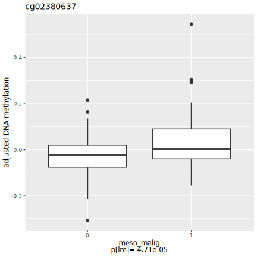

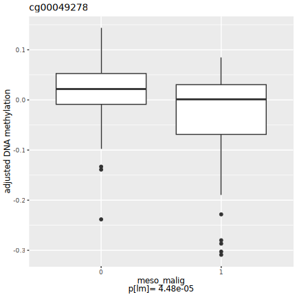

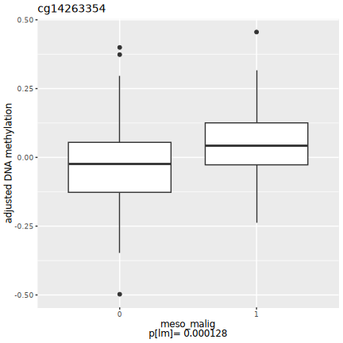

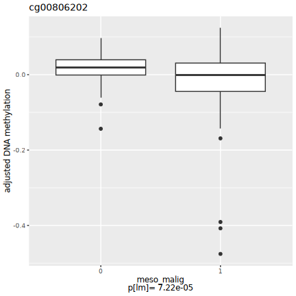

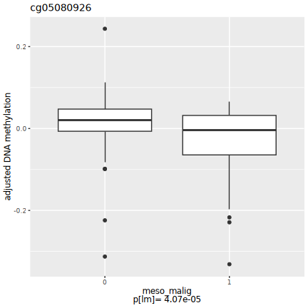

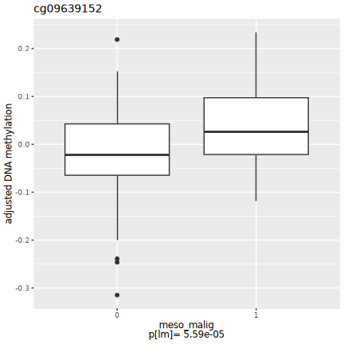

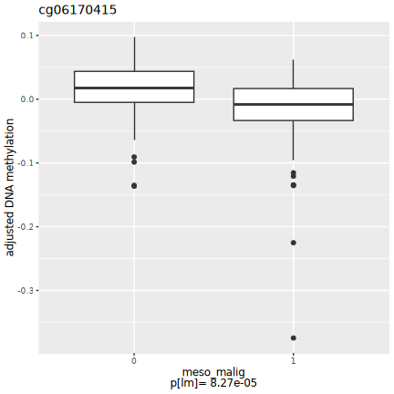

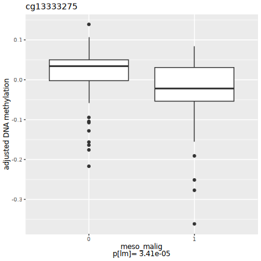

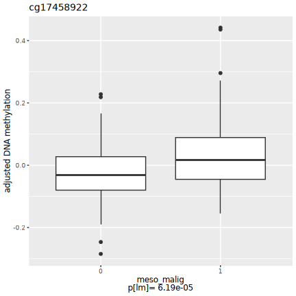

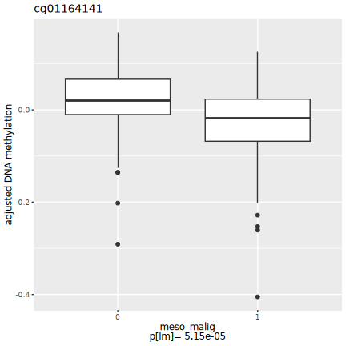

## Selected CpG sites

Number of CpG sites selected: 0.

| chromosome | position | estimate | p.value | p.adjust |
| --- | --- | --- | --- | --- |